# Questionnaire Report for California Halibut

(MERA version 4.1.6)

Brett van Poorten (brett.vanpoorten@gmail.com)

2019-07-10

# 1 About this document

This is a prototype of an automatic report that documents how the user specified the operating model and their various justifications.

# 2 Introduction

1. Describe the history and current status of the fishery, including fleets, sectors, vessel types and practices/gear by vessel type, landing ports, economics/markets, whether targeted/bycatch, other stocks caught in the fishery. California halibut are targeted by bottom trawl, single-rigged trawl, trawl with foot rope <8 in, hook and line, gill net, and recreational fisheries . Fish are landed at ports along the coast. The species is separated into a south and central stock; delineated by Point Conception. History of the fishery, taken from Appendix 1 of the stock assessment (Historical Management Actions for California Halibut Fisheries.pdf): “1876- The proto-trawl net, known as the paranzella net and which is towed by two boats, is introduced in San Francisco. 1880s- Entangling nets, including trammel nets, are introduced in California. 1911- Trammel nets are prohibited in state waters. 1913- Trammel nets are permitted but required to be pulled within 6 hours. 1913- Trawl nets are prohibited in state waters off the coast of Los Angeles, Ventura, Orange, and San Diego counties. Trawl nets are prohibited within Monterey Bay. 1915- Trawling is prohibited in all state waters. 1915- California halibut less than 4 lbs (1.8 kg) in the round cannot be bought or sold. 1925- Legislation is changed to allow trawling off the coast of Santa Barbara within state waters. 1931- Commercially-caught California halibut less than 3.5 lbs (1.6 kg) dressed with the head on or 3 lbs (1.4 kg) dressed with the head off cannot be bought or sold (Recreationally-caught halibut may never be bought or sold). Up to 30 lbs (13.5 kg) of underweight California halibut can be retained by a commercial fisherman for personal use only. 1936- Market category for California halibut is established on landing receipts to distinguish from Pacific halibut. 1953- Waters off the Santa Barbara coast are closed to trawling again and trawling is prohibited in all state waters. 1968- Trawl nets are authorized between Point Sur and Cape San Martin in waters not less than 1 nm from the mainland shore. Trawl nets are also permitted between Point Arguello and El Capitan Point in Santa Barbara County in waters not less than 25 fathoms (fm) or 1 nm from shore. 1971- A minimum size limit of 22 inches total length (TL) for all recreationally-landed California halibut is established. 1971- A recreational bag limit of three fish north of Point Sur and five fish south of Point Sur is established. 1971- The California Halibut Trawl Grounds (CHTG) are established in southern California (Fish and Game Code sec. 8495). 1971- A 4-month trawl closure within the CHTG is implemented from February through May to protect spawning adults. 1972- A minimum mesh size of 7.5 inches is established for the cod end of trawl nets used within the CHTG. 1973- The 4-month trawl closure within the CHTG is changed to 15 March to 15 June. 1975- A minimum mesh size of 4.5 inches for the mesh of any part of a groundfish trawl net is established. This still applies to federal waters where halibut fishing occurs. 1979- A minimum size limit of 22 inches TL for all commercially-landed California halibut is established. For any licensed commercial fisherman, up to 30 pounds of halibut per day below minimum legal size may be possessed for personal use if taken incidentally in commercial fishing. 1985- Minimum mesh size for gill and trammel nets used to take halibut is increased to 8.5 inches (216 mm) between Point Dume (Los Angeles County) and Ragged Point (San Luis Obispo County). 1985- The number of halibut less than 22 inches total length that may be possessed by commercial fishermen for personal use is reduced to four fish. 1989- An 8.5-inch (216 mm) minimum mesh size for gill and trammel nets used to take halibut is adopted statewide. Gill and trammel nets are prohibited in Santa Monica Bay. 1989- The definition of the CHTG is amended and the 25-fm clause is removed. 1994- The Marine Resources Protection Zone is established by legislation: it prohibits the use of gill nets within 3 nm of shore south of Point Conception and within 1 nm from shore or 70 fm (whichever is less) around the Channel Islands. 2000- An emergency closure is established in waters less than 60 fm from Point Reyes to Point Arguello for the use of gill nets to take halibut. 2002- A permanent closure is established in waters less than 60 fm from Point Reyes to Point Arguello for the use of gill nets to take halibut. 2004- Senate Bill 1459 gives the Fish and Game Commission (Commission) authority over the management of the California halibut bottom trawl fishery. 2004- No halibut less than 22 inches total length may be taken, possessed or sold. 2004- SB 1459 closes all state waters to bottom trawling, with the exception of the CHTG. This includes historic trawl grounds for halibut within state waters of Monterey Bay which are greater than 3 nm from shore. However, the Monterey Bay trawl closure is not enforced until 2006. 2005- Due to SB 1459, 13 percent of the CHTG are closed to bottom trawling. These are the only state waters to date in which bottom trawling is allowed. 2006 A California halibut bottom trawl vessel permit is required for any commercial trawl vessel to land halibut taken in state waters, and in federal waters for landings exceeding 150 pounds 2008- Due to SB 1459, an additional section of the CHTG is closed to bottom trawling. 2009- Commission establishes regulations defining “light touch” trawl gear as the only trawl gear allowed within the CHTG." Frimodig et al. (2008) Appendix B shows other species caught (many bottom fish, sharks and rays).
2. Describe the stock’s ecosystem functions, dependencies, and habitat types. California halibut occur in shallow nursery areas to depths up to 185m, though most catch is less than 60m. Juveniles eat invertebrates and larval fish. As they grow, they start eating anchovies, which become their main diet; but their diet also includes other small fish and shrimp (see full summary of diet and references in Haugen 1980; The California Halibut, Paralichthys californicus, Resource and Fisheries.pdf)
3. Provide all relevant reference materials, such as assessments, research, and other analysis. Haugen et al. 1980: The California Halibut, Paralichthys californicus, Resource and Fisheries California Halibut Stock Assessment Background Information.pdf Central California Stock Assessment of California Halibut.pdf Historical Management Actions for California Halibut Fisheries.pdf Southern California Stock Assessment of California halibut.pdf Stock Assessment Summary for California Halibut.pdf The California Halibut, Paralichthys californicus, Resource and Fisheries.pdf

# 3 Fishery Characteristics

## 3.1 Longevity

| Answered |
| --- |
| Very short-lived (5 < maximum age < 7) |
| Short-lived (7 < maximum age < 10) |
| Moderate life span (10 < maximum age < 20) |
| Moderately long-lived (20 < maximum age < 40) |
| Long-lived (40 < maximum age < 80) |
| Very long-lived (80 < maximum age < 160) |

[output not shown]

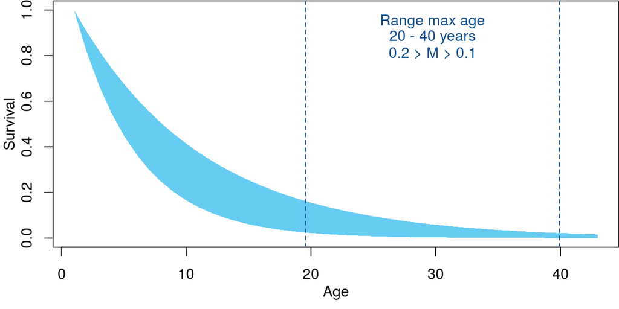

## 3.2 Stock depletion

| Answered |
| --- |
| Crashed (D < 0.05) |
| Very depleted (0.05 < D < 0.1) |
| Depleted (0.1 < D < 0.15) |
| Moderately depleted (0.15 < D < 0.3) |
| Healthy (0.3 < D < 0.5) |
| Underexploited (0.5 < D) |

[output not shown]

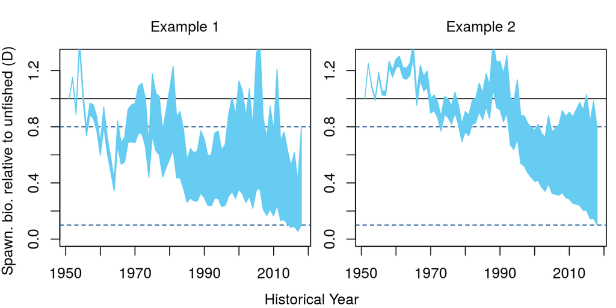

## 3.3 Resilence

| Answered |
| --- |
| Not resilient (steepness < 0.3) |
| Low resilience (0.3 < steepness < 0.5) |
| Moderate resilence (0.5 < steepness < 0.7) |
| Resilient (0.7 < steepness < 0.9) |
| Very Resilient (0.9 < steepness) |

Justification

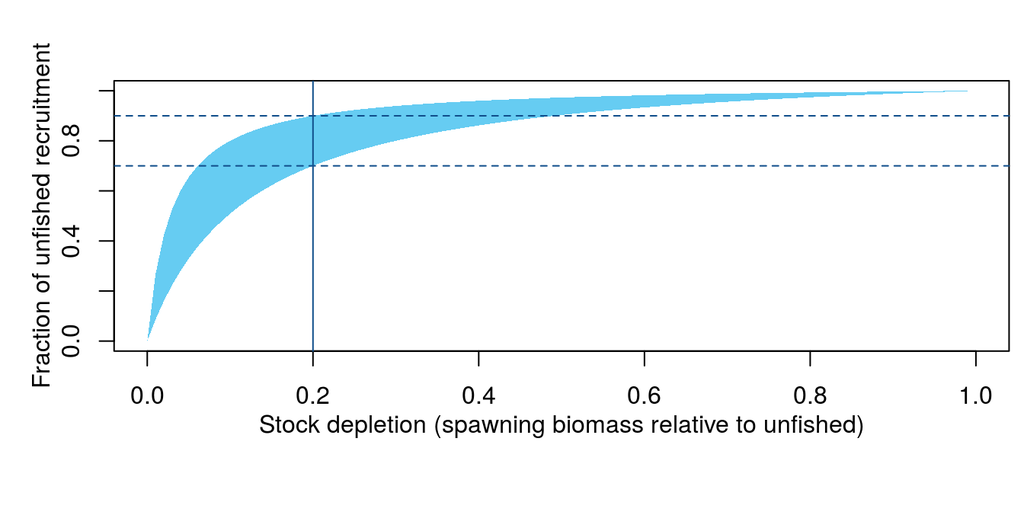

## 3.4 Historical effort pattern

| Answered |
| --- |
| Stable |
| Two-phase |
| Boom-bust |
| Gradual increases |
| Stable, recent increases |
| Stable, recent declines |

| Justification |
| --- |
| Again, no information on effort. This is a relatively long lived species with episodic recruitment, so catches should somewhat mimic effort. Catches have shown reasonable variation. |

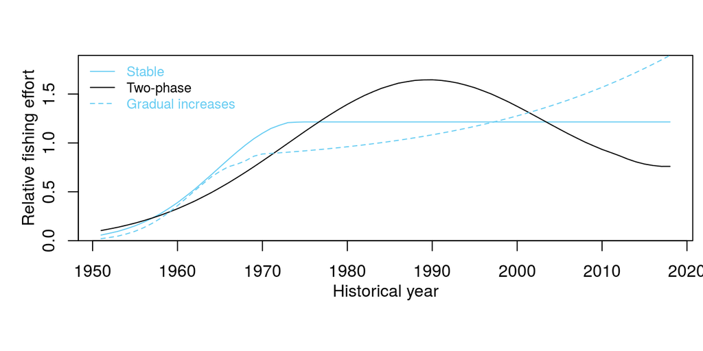

## 3.5 Inter-annual variability in historical effort

| Answered |
| --- |
| Not variable (less than 20% inter-annual change (IAC)) |
| Variable (maximum IAC between 20% to 50%) |
| Highly variable (maximum IAC between 50% and 100%) |

| Justification |
| --- |
| Again, no information on effort. This is a relatively long lived species with episodic recruitment, so catches should somewhat mimic effort. Catches have shown reasonable variation. |

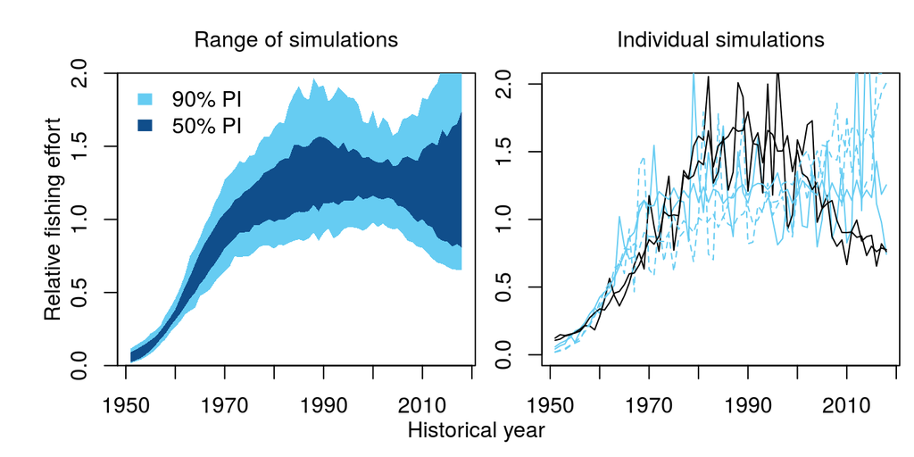

## 3.6 Historical fishing efficiency changes

| Answered |
| --- |
| Declining by 2-3% pa (halves every 25-35 years) |
| Declining by 1-2% pa (halves every 35-70 years) |
| Stable -1% to 1% pa (may halve/double every 70 years) |
| Increasing by 1-2% pa (doubles every 35-70 years) |
| Increasing by 2-3% pa (doubles every 25-35 years) |

| Justification |
| --- |
| No information available; catches should increase nominally as technology improves. |

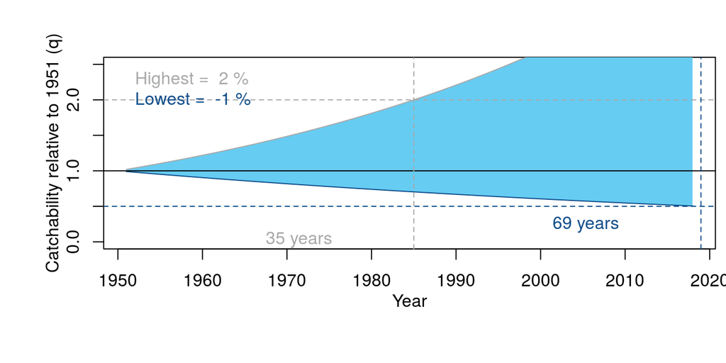

## 3.7 Future fishing efficiency changes

| Answered |
| --- |
| Declining by 2-3% pa (halves every 25-35 years) |
| Declining by 1-2% pa (halves every 35-70 years) |
| Stable -1% to 1% pa (may halve/double every 70 years) |
| Increasing by 1-2% pa (doubles every 35-70 years) |
| Increasing by 2-3% pa (doubles every 25-35 years) |

| Justification |
| --- |
| No information available. I think they direction of change is unknown. |

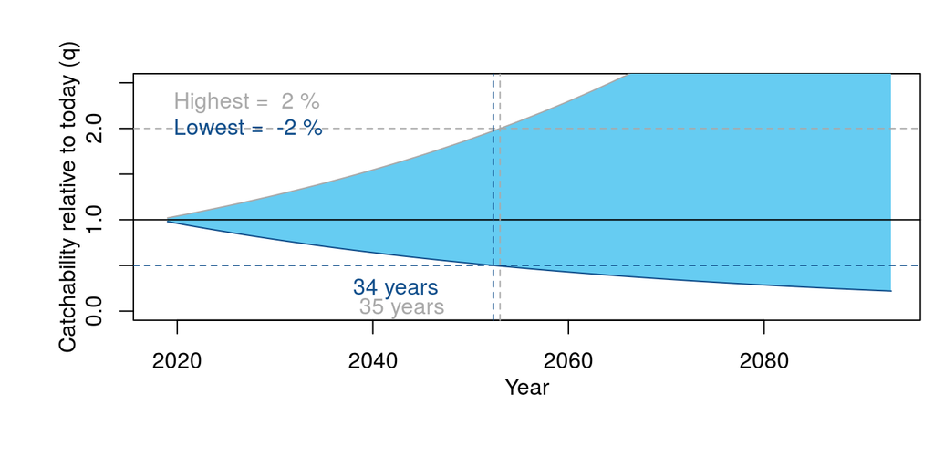

## 3.8 Length at maturity

| Answered |
| --- |
| Very small (0.4 < LM < 0.5) |
| Small (0.5 < LM < 0.6) |
| Moderate (0.6 < LM < 0.7) |
| Moderate to large (0.7 < LM < 0.8) |
| Large (0.8 < LM < 0.9) |

[output not shown]

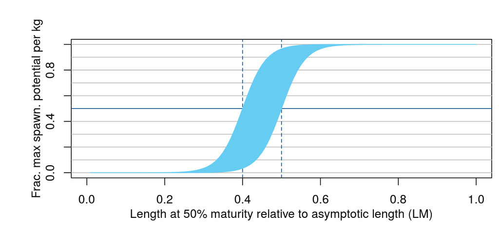

## 3.9 Selectivity of small fish

| Answered |
| --- |
| Very small (0.1 < S < 0.2) |
| Small (0.2 < S < 0.4) |
| Half asymptotic length (0.4 < S < 0.6) |
| Large (0.6 < S < 0.8) |
| Very large (0.8 < S < 0.9) |

| Justification |
| --- |
| Linf for males and females is ~1000 and ~1400 mm, respectively; length at maturity is ~230 and ~470 mm, respectively, meaning a length at maturity <<0.5. |

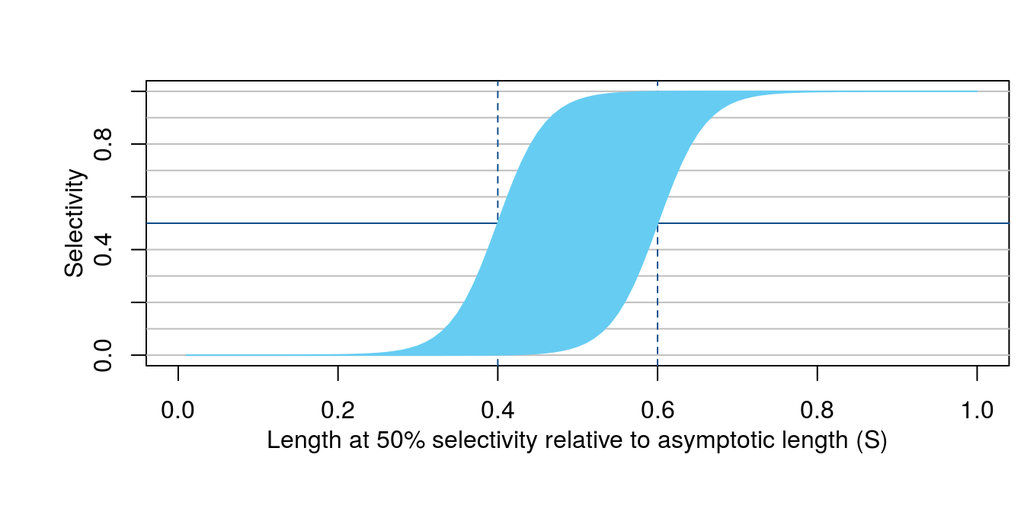

## 3.10 Selectivity of large fish

| Answered |
| --- |
| Asymptotic selectivity (SL = 1) |
| Declining selectivity with length (0.75 < SL < 1) |
| Dome-shaped selectivity (0.25 < SL < 0.75) |
| Strong dome-shaped selectivity (SL < 0.25) |

| Justification |
| --- |
| Fish migrate offshore; as such the decline in selectivity varies by fishery. Selectivity curves are shown in stock assessment documents for the central and southern stocks. |

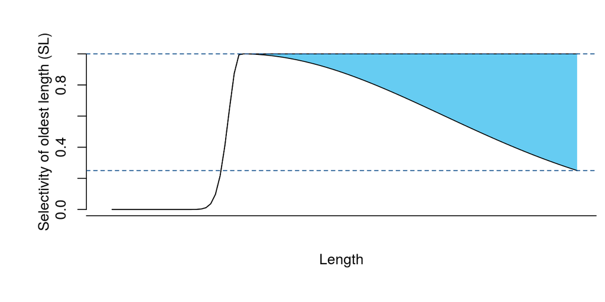

## 3.11 Discard rate

| Answered |
| --- |
| Low (DR < 1%) |
| Low - moderate (1% < DR < 10%) |
| Moderate (10% < DR < 30%) |
| Moderate - high (30% < DR < 50%) |
| High (50% < DR < 70%) |

[output not shown]

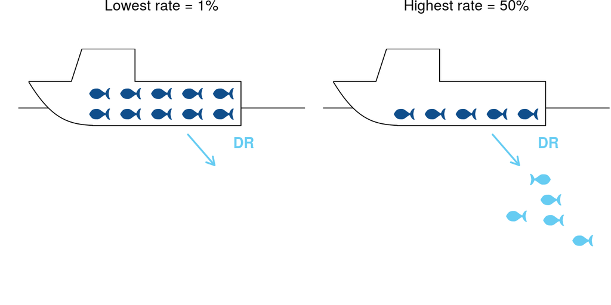

## 3.12 Post-release mortality rate

| Answered |
| --- |
| Low (PRM < 5%) |
| Low - moderate (5% < PRM < 25%) |
| Moderate (25% < PRM < 50%) |
| Moderate - high (50% < PRM < 75%) |
| High (75% < PRM < 95%) |
| Almost all die (95% < PRM < 100%) |

| Justification |
| --- |
| “Discarded fish from the recreational fisheries can be substantial.” (California Halibut Stock Assessment Background Information.pdf) |

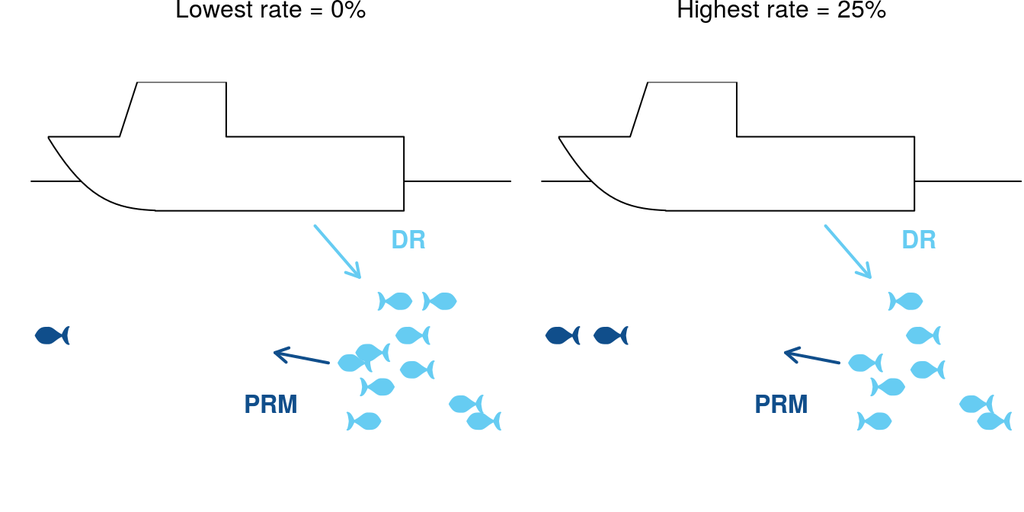

## 3.13 Recruitment variability

| Answered |
| --- |
| Very low (less than 10% inter-annual changes (IAC)) |
| Low (max IAC of between 20% and 60%) |
| Moderate (max IAC of between 60% and 120%) |
| High (max IAC of between 120% and 180%) |
| Very high (max IAC greater than 180%) |

[output not shown]

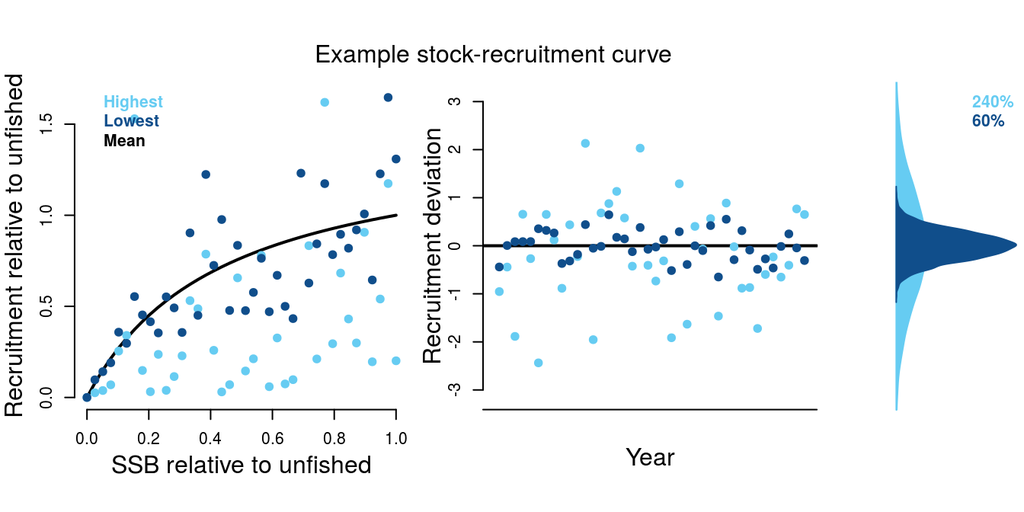

## 3.14 Size of an existing MPA

| Answered |
| --- |
| None |
| Small (A < 5%) |
| Small-moderate (5% < A < 10%) |
| Moderate (10% < A < 20%) |
| Large (20% < A < 30%) |
| Very large (30% < A < 40%) |
| Huge (40% < A < 50%) |

[output not shown]

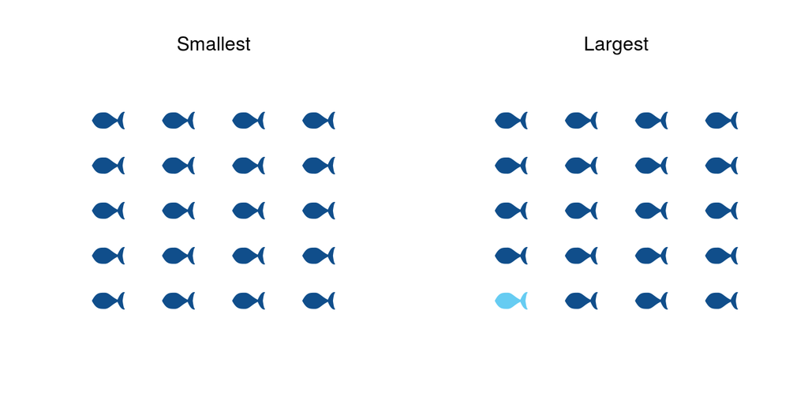

## 3.15 Spatial mixing (movement) in/out of existing MPA

| Answered |
| --- |
| Very low (P < 1%) |
| Low (1% < P < 5%) |
| Moderate (5% < P < 10%) |
| High (10% < P < 20%) |
| Fully mixed |

| Justification |
| --- |
| Several closed areas exist; some are applied to all fisheries, others to only some fleets (i.e. bottom trawls). Total closed area is small (see Frimodig et al. 2008; Figures 1 and 2) |

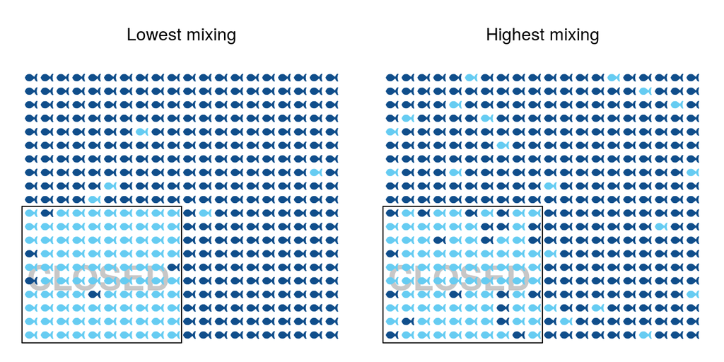

## 3.16 Size of a future potential MPA

| Answered |
| --- |
| None |
| Small (A < 5%) |
| Small-moderate (5% < A < 10%) |
| Moderate (10% < A < 20%) |
| Large (20% < A < 30%) |
| Very large (30% < A < 40%) |
| Huge (40% < A < 50%) |

| Justification |
| --- |
| No new closures are being considered. |

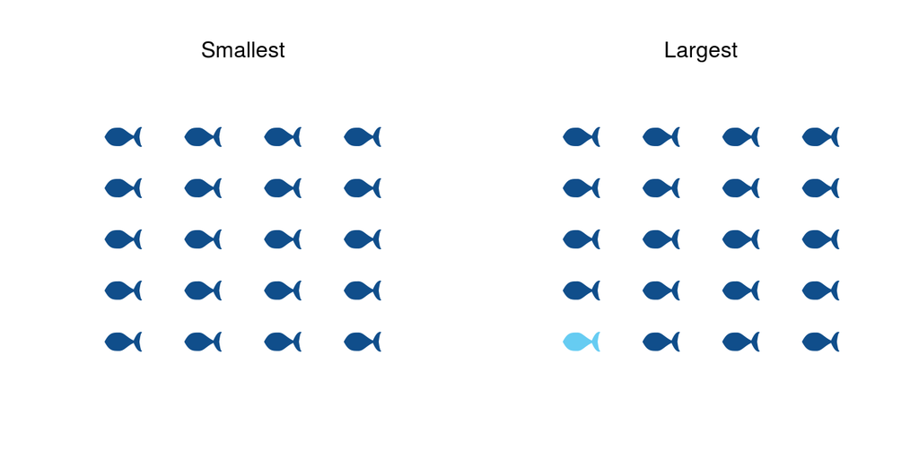

## 3.17 Spatial mixing (movement) in/out of future potential MPA

| Answered |
| --- |
| Very low (P < 1%) |
| Low (1% < P < 5%) |
| Moderate (5% < P < 10%) |
| High (10% < P < 20%) |
| Fully mixed |

| Justification |
| --- |
| This is a relatively wide ranging species. Closed areas are generally to protect undersized fish rather than limit mortality of targeted stock. |

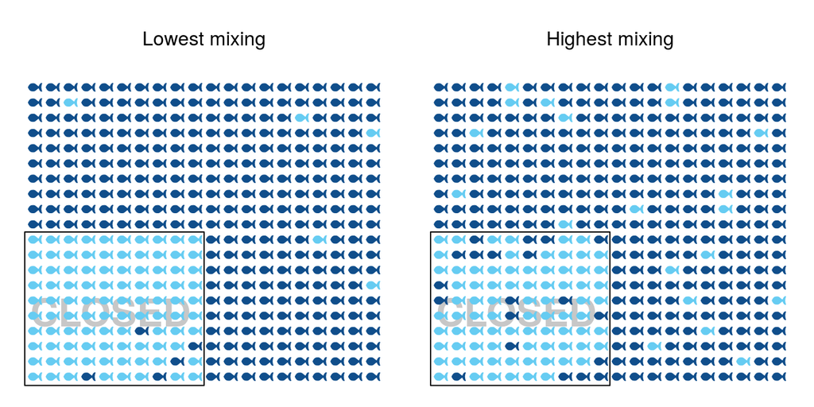

## 3.18 Initial stock depletion

| Answered |
| --- |
| Very low (0.1 < D1 < 0.15) |
| Low (0.15 < D1 < 0.3) |
| Moderate (0.3 < D < 0.5) |
| High (0.5 < D1) |
| Asymptotic unfished levels (D1 = 1) |

| Justification |
| --- |
| Southern stock was initially quite depleted (D~0.18 as of 1982 when the assessment began); Central stock was relatively healthy (D~0.7). |

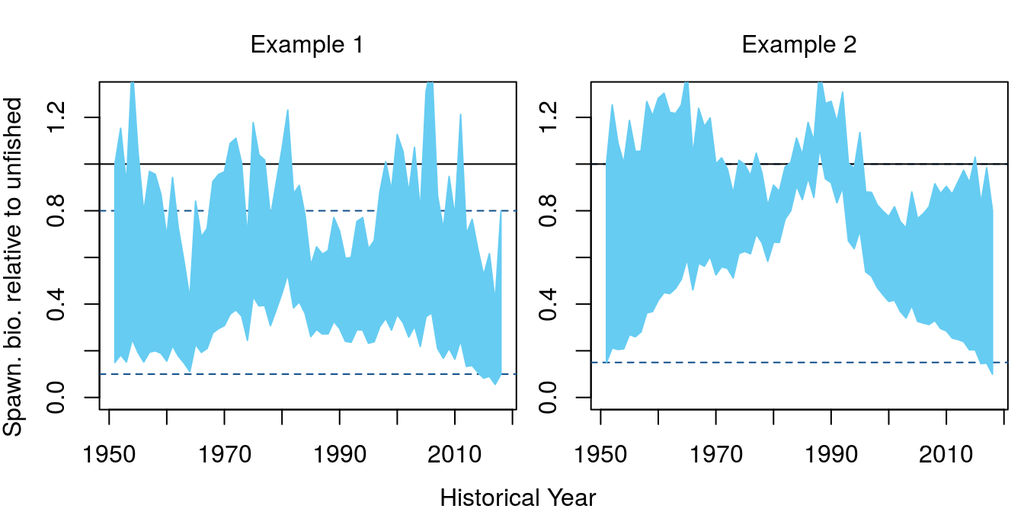

# 4 Management Characteristics

## 4.1 Types of fishery management that are possible

| Answered |
| --- |
| TAC (Total Allowable Catch): a catch limit |
| TAE (Total Allowable Effort): an effort limit |
| Size limit |
| Time-area closures (a marine reserve) |

[output not shown]

## 4.2 TAC offset: consistent overages/underages

| Answered |
| --- |
| Large underages (40% - 70% of recommended) |
| Underages (70% - 90% of recommended) |
| Slight underages (90% - 100% of recommended) |
| Taken exactly (95% - 105% of recommended) |
| Slight overages (100% - 110% of recommended) |
| Overages (110% - 150% of recommended) |
| Large overages (150% - 200% of recommended) |

| Justification |
| --- |
| No justification was provided |

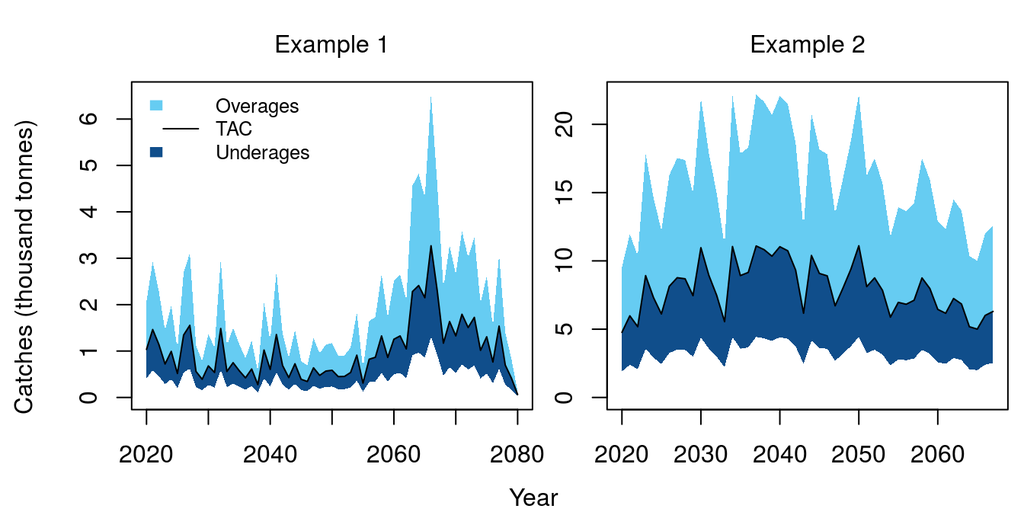

## 4.3 TAC implementation variability

| Answered |
| --- |
| Constant (V < 1%) |
| Not variable (1% < V < 5%) |
| Low variability (5% < V < 10%) |
| Variable (10% < V < 20%) |
| Highly variable (20% < V < 40%) |

| Justification |
| --- |
| No justification was provided |

## 4.4 TAE offset: consistent overages/underages

| Answered |
| --- |
| Large underages (40% - 70% of recommended) |
| Underages (70% - 90% of recommended) |
| Slight underages (90% - 100% of recommended) |
| Taken exactly (95% - 105% of recommended) |
| Slight overages (100% - 110% of recommended) |
| Overages (110% - 150% of recommended) |
| Large overages (150% - 200% of recommended) |

| Justification |
| --- |
| No justification was provided |

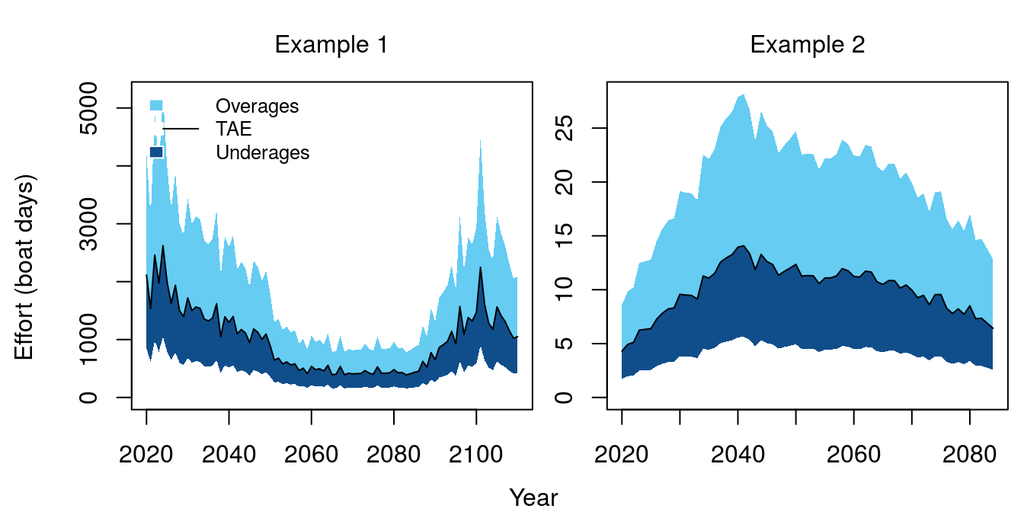

## 4.5 TAE implementation variability

| Answered |
| --- |
| Constant (V < 1%) |
| Not variable (1% < V < 5%) |
| Low variability (5% < V < 10%) |
| Variable (10% < V < 20%) |
| Highly variable (20% < V < 40%) |

| Justification |
| --- |
| No justification was provided |

## 4.6 Size limit offset: consistent overages/underages

| Answered |
| --- |
| Much smaller (40% - 70% of recommended) |
| Smaller (70% - 90% of recommended) |
| Slightly smaller (90% - 100% of recommended) |
| Taken exactly (95% - 105% of recommended) |
| Slightly larger (100% - 110% of recommended) |
| Larger (110% - 150% of recommended) |
| Much larger (150% - 200% of recommended) |

| Justification |
| --- |
| No justification was provided |

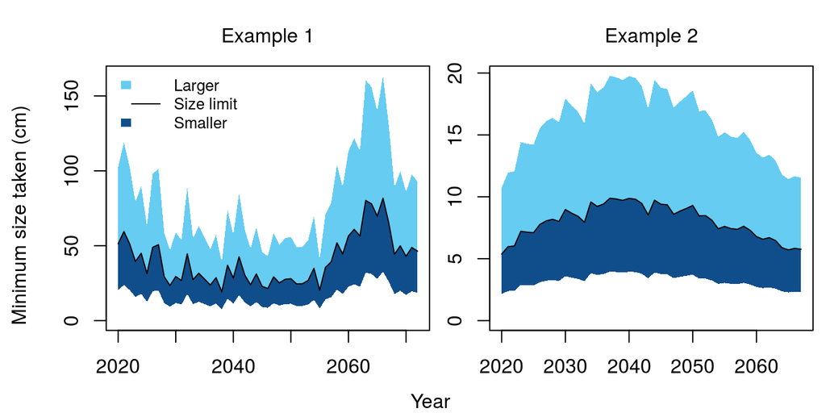

## 4.7 Size limit implementation variability

| Answered |
| --- |
| Constant (V < 1%) |
| Not variable (1% < V < 5%) |
| Low variability (5% < V < 10%) |
| Variable (10% < V < 20%) |
| Highly variable (20% < V < 40%) |

| Justification |
| --- |
| No justification was provided |

# 5 Data Characteristics

## 5.1 Available data types

| Answered |
| --- |
| Historical annual catches (from unfished) |
| Recent annual catches (at least 5 recent years) |
| Historical relative abundance index (from unfished) |
| Recent relative abundance index (at least 5 recent years) |
| Fishing effort |
| Size composition (length samples) |
| Age composition (age samples) |
| Growth (growth parameters) |
| Absolute biomass survey |

Justification

1. Provide the time series (specify years, if possible) that exist for catch, effort, and CPUE/abundance indices.  
Central stock:  
Catch data from bottom trawl, single-rigged trawl, trawl with foot rope <8 in, hook and line, gill net, and recreational fisheries are available from 1980-2010.  
Abundance indices are also available for 1980-2010 for North, Central and Southern areas from Commercial Passenger Fishing Vessel (CPFV) logbooks; for 1980-1989 from trawl logbooks and Delta Bay study.  
Length composition data are available from 2007-2010 from commercial data; length and weight composition data are available for groups of years (but not all years across all sources) from 1980-2010  
Age composition and length-age data are only available for short periods of time.  
Southern stock:  
CPFV logbook data were used to generate the abundance index from 1980-2010  
Length composition data come from (Southern California Stock Assessment of California halibut.pdf):  
California Department of Fish and Game’s (CDFG) State Finfish Management Project (2007-2010) and market sampling (1983-2006)  
The length composition data on the retained and discarded halibut that are available from the gill net observer program (1983-1989) were included in the model to estimate the gill net retention curve.  
Recreational length composition data (unsexed) of the whole catch (retained plus discarded) in the CPFV fishery comes from the observer sampling (1975-1978 and 1986-1989) and retained catch comes from the Recreational Fisheries Information Network (RecFIN) (1993-2010)  
Weight composition data from the retained catch for the recreational fisheries is also available from the RecFIN (1980-1989) database  
Length composition data is also available for the fishery-independent surveys (impingement, impingement trawls, sanitation trawls, and gill net surveys; Table B2.8.3, Figure B2.8.3)  
Age composition is either from multiple fisheries combined or is biased, so has not been used in the assessment  
Estimates of recreational discard rates are available from RecFIN, CPFV observers, and CPFV logbooks  
“Commercial discards are available from the federal observer program on halibut trawl trips, both limited entry and open access (Table B2.10.3, Figure B2.10.2). However, most of the data is from north of Point Conception and samples sizes are low. Limited data is available on the size composition of the discards (Figure B2.10.3.). An annual series of discard rates is available (e.g., see Bellman et al. 2010). Discard length composition data is available for the gill net fishery from the gill net observer program” (Southern California Stock Assessment of California halibut.pdf)  
2. Describe how these data collected (e.g., log books, dealer reporting, observers).  
CPFV data are from logbooks  
Length frequency data are from market sampling, observer programs (gill net fishery),  
Age frequency data tend to come from individual research projects  
Discard data come from observers, logbooks and the RecFIN database  
3. Describe what types of sampling programs and methodologies exist for data collection, including the time-series of available sampling data and quality.  
California Recreational Fisheries Survey is a stratified survey of recreational anglers aimed at getting catch and effort data  
“The State Finfish Management Project (SFMP) obtains basic length, weight, age, and reproductive information from sampled landings in central and southern California ports (CDFW 2013).”  
The state-operated observer program is subject to funding limitations so can be patchy  
4. Describe all sources of uncertainty in the status, biology, life history and data sources of the fishery. Include links to documentation, reports.  
“There is substantial uncertainty about many of the biological and fishing processes including the stock-recruitment relationship, natural mortality, growth, and the survival of discarded fish.” (Southern California Stock Assessment of California halibut.pdf)

## 5.2 Catch reporting bias

| Answered |
| --- |
| Strong under-reporting (30% - 50%) |
| Under-reporting (10% - 30%) |
| Slight under-reporting (less than 10%) |
| Reported accurately (+/- 5%) |
| Slight over-reporting (less than 10%) |

| Justification |
| --- |
| No information on catch reporting bias. There is substantial reliance on logbooks, rather than observer programs. This suggests that underreporting may be occurring |

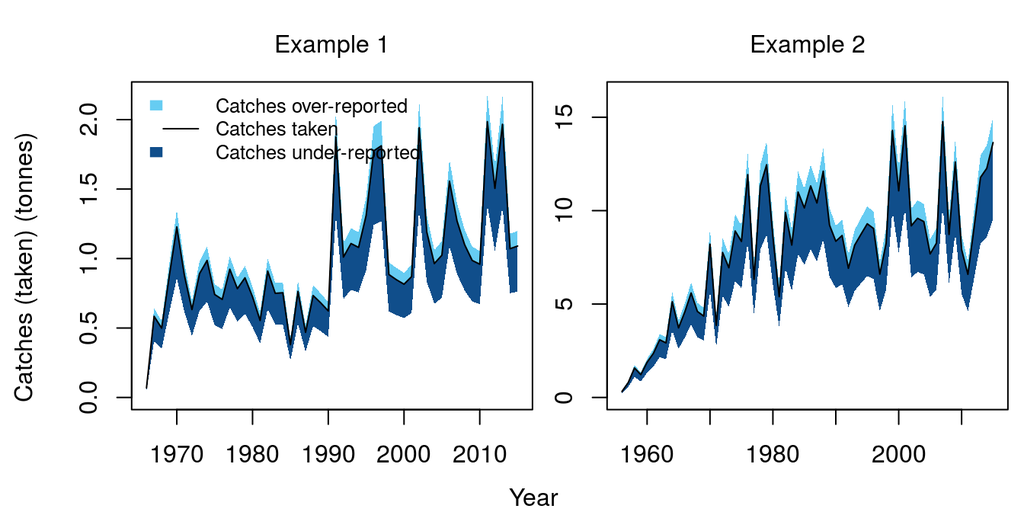

## 5.3 Hyperstability in indices

| Answered |
| --- |
| Strong hyperdepletion (2 < Beta < 3) |
| Hyperdepletion (1.25 < Beta < 2) |
| Proportional (0.8 < Beta < 1.25) |
| Hyperstability (0.5 < Beta < 0.8) |
| Strong hyperstability (0.33 < Beta < 0.5) |

[output not shown]

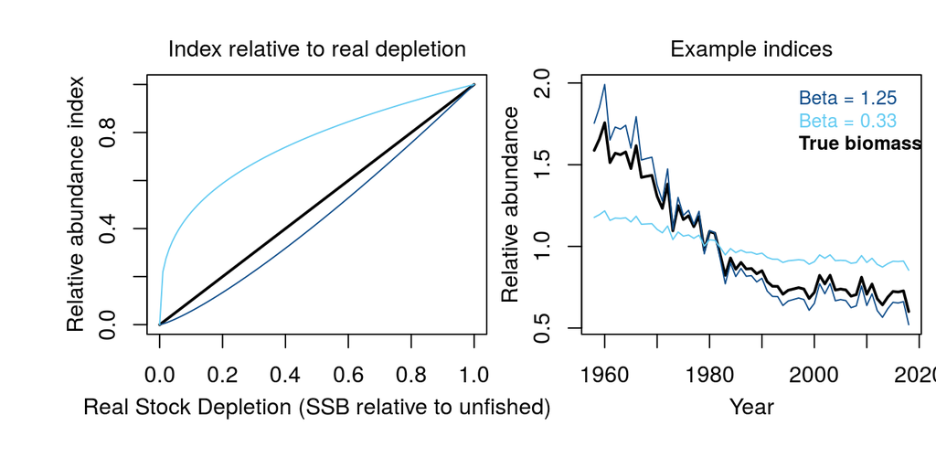

| Answered |
| --- |
| Perfect |
| Good (accurate and precise) |
| Data moderate (some what inaccurate and imprecise) |
| Data poor (inaccurate and imprecise) |

| Justification |
| --- |
| Indices are based on fishery data, length/age composition (especially for the southern stock) are limited. |

# 6 Version Notes

The package is subject to ongoing testing. If you find a bug or a problem please send a report to t.carruthers@oceans.ubc.ca so that it can be fixed!

shiny-2019-07-10-22:24:54

Open Source, GPL-2 2019